# hw3

Ali Seyit Zararsız 2017402045

06 06 2021

# Introduction

In this report, I will study the hourly electricity consumption of Turkey and try to predict the next 14 days’ consumption with an appropriate ARMA model. The dates include 1st of January 2016 until 20th of May 2021. All data used for this study is publicly available in Transparency Platform by EPİAŞ.

#Data Preparation

```r
consumptiondata=fread('RealTimeConsumption-01012016-20052021.csv')


#str(consumptiondata)
setnames(consumptiondata, 3, "Consumption")
consumptiondata[,Consumption:=as.numeric(gsub(",", "", Consumption))]
consumptiondata[,datetime:=paste(Date,Hour)]
consumptiondata[,datetime:=as.POSIXct(datetime, format= "%d.%m.%Y %H:%M" ,tz="UTC")]
#head(consumptiondata)
str(consumptiondata)
```

```
## Classes 'data.table' and 'data.frame':   47208 obs. of  4 variables:
##  $ Date       : chr  "01.01.2016" "01.01.2016" "01.01.2016" "01.01.2016" ...
##  $ Hour       : chr  "00:00" "01:00" "02:00" "03:00" ...
##  $ Consumption: num  26277 24992 23533 22465 22003 ...
##  $ datetime   : POSIXct, format: "2016-01-01 00:00:00" "2016-01-01 01:00:00" ...
##  - attr(*, ".internal.selfref")=<externalptr>
```

```r
head(consumptiondata)
```

```
##          Date  Hour Consumption            datetime
## 1: 01.01.2016 00:00    26277.24 2016-01-01 00:00:00
## 2: 01.01.2016 01:00    24991.82 2016-01-01 01:00:00
## 3: 01.01.2016 02:00    23532.61 2016-01-01 02:00:00
## 4: 01.01.2016 03:00    22464.78 2016-01-01 03:00:00
## 5: 01.01.2016 04:00    22002.91 2016-01-01 04:00:00
## 6: 01.01.2016 05:00    21957.08 2016-01-01 05:00:00
```

# Seasonality Analysis

I think that electric consumption should be affected from hours of the day, days of the week and month of the year. So I will search any seasonality patterns in these time regions.

## Hourly Seasonality Analysis

Let me start with hourly seasonality since everbody’s behavior of consuming electricity changes from day to night. The data will be converted to a time series data with a frequency of 24.

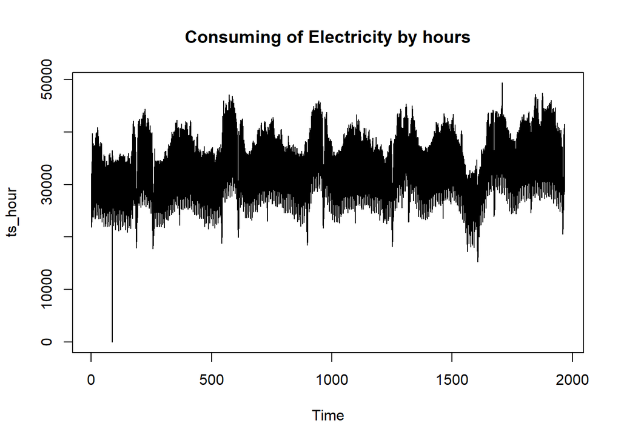

```r
hourly = consumptiondata[, Consumption]
ts_hour<-ts(hourly, freq=24)
ts.plot(ts_hour,main="Consuming of Electricity by hours")
```

We see an outlier in the first year which maybe caused by a huge shutdown in the big cities or factories. We also see a slightly increasing trend throughout the time and some seasonality. The decrease in the late part of the time series data is the conclusion of the decision that the government made during coronavirus pandemic.

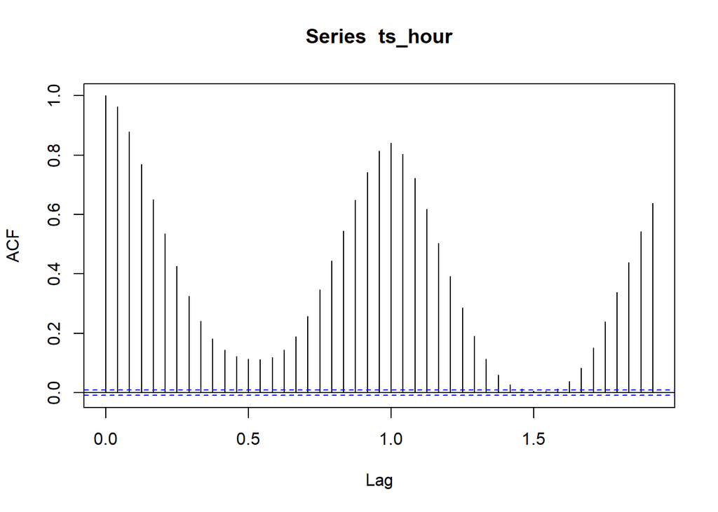

```r
acf(ts_hour)
```